# 02_points_on_sqrtx

## 02_points_on_sqrtx

#### Question

1. Consider the $y=\sqrt{x}$ curve shown below (the square root function). There are 6 points along the curve, find the missing coordinates of those points in the table.

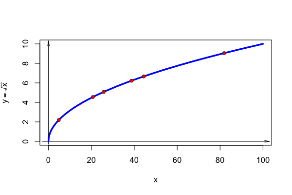

   | $x$ | $y=\sqrt{x}$ |
   | --- | --- |
   | 4.8 |  |
   |  | 4.55 |
   | 25.7 |  |
   |  | 6.22 |
   | 44.4 |  |
   |  | 9.05 |

#### Solution

#### Question

2. Consider the $y=\sqrt{x}$ curve shown below (the square root function). There are 6 points along the curve, find the missing coordinates of those points in the table.

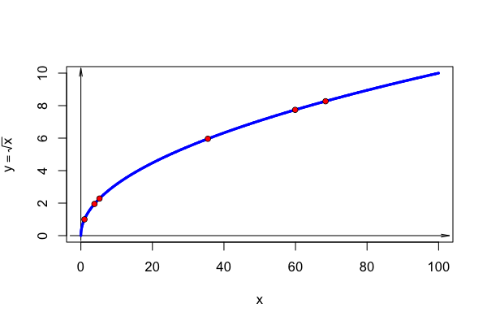

   | $x$ | $y=\sqrt{x}$ |
   | --- | --- |
   | 1 |  |
   |  | 1.95 |
   | 5.2 |  |
   |  | 5.96 |
   | 59.9 |  |
   |  | 8.27 |

#### Solution

#### Question

3. Consider the $y=\sqrt{x}$ curve shown below (the square root function). There are 6 points along the curve, find the missing coordinates of those points in the table.

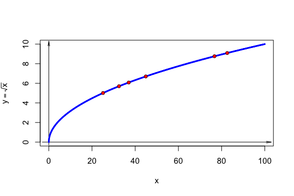

   | $x$ | $y=\sqrt{x}$ |
   | --- | --- |
   | 25.1 |  |
   |  | 5.7 |
   | 37 |  |
   |  | 6.7 |
   | 76.7 |  |
   |  | 9.09 |

#### Solution

#### Question

4. Consider the $y=\sqrt{x}$ curve shown below (the square root function). There are 6 points along the curve, find the missing coordinates of those points in the table.

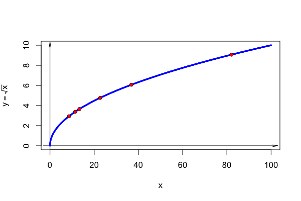

   | $x$ | $y=\sqrt{x}$ |
   | --- | --- |
   | 8.6 |  |
   |  | 3.38 |
   | 13.3 |  |
   |  | 4.76 |
   | 36.8 |  |
   |  | 9.06 |

#### Solution

#### Question

5. Consider the $y=\sqrt{x}$ curve shown below (the square root function). There are 6 points along the curve, find the missing coordinates of those points in the table.

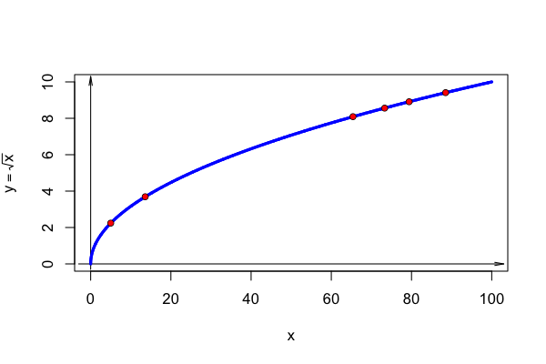

   | $x$ | $y=\sqrt{x}$ |
   | --- | --- |
   | 5 |  |
   |  | 3.69 |
   | 65.4 |  |
   |  | 8.56 |
   | 79.4 |  |
   |  | 9.41 |

#### Solution

#### Question

6. Consider the $y=\sqrt{x}$ curve shown below (the square root function). There are 6 points along the curve, find the missing coordinates of those points in the table.

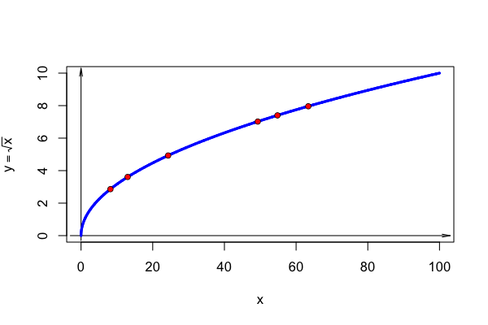

   | $x$ | $y=\sqrt{x}$ |
   | --- | --- |
   | 8.2 |  |
   |  | 3.61 |
   | 24.3 |  |
   |  | 7.02 |
   | 54.8 |  |
   |  | 7.96 |

#### Solution

#### Question

7. Consider the $y=\sqrt{x}$ curve shown below (the square root function). There are 6 points along the curve, find the missing coordinates of those points in the table.

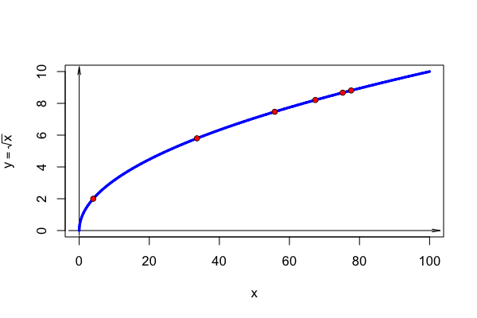

   | $x$ | $y=\sqrt{x}$ |
   | --- | --- |
   | 4 |  |
   |  | 5.8 |
   | 55.8 |  |
   |  | 8.21 |
   | 75.2 |  |
   |  | 8.81 |

#### Solution

#### Question

8. Consider the $y=\sqrt{x}$ curve shown below (the square root function). There are 6 points along the curve, find the missing coordinates of those points in the table.

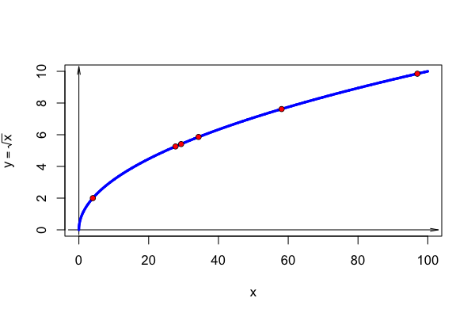

   | $x$ | $y=\sqrt{x}$ |
   | --- | --- |
   | 4 |  |
   |  | 5.26 |
   | 29.3 |  |
   |  | 5.86 |
   | 58.1 |  |
   |  | 9.85 |

#### Solution